# User Avatar Bond Discrepancy Questionnaire

Taylor Brown

2022-04-06

EFA completed via Jamovi - No syntax was used

First Step for CFA run packages if already installed

```
## ###############################################################################
```

```
## All users of R (or SEM) are invited to submit functions or ideas for functions.
```

```
## ###############################################################################
```

Second - import the dataset and define model

```r
CFAdata<-haven::read_sav("CFA-Data.sav")%>%
  mutate_if(is.character, as.factor)
describe(CFAdata)
```

```
##             vars   n    mean      sd median trimmed     mad min  max range
## ID             1 236 4979.19 2773.48 4862.5 5038.55 3656.83   1 9458  9457
## w2_res1        2 236    3.43    1.27    3.0    3.45    1.48   1    6     5
## w2_res2        3 236    3.35    1.30    3.0    3.32    1.48   1    7     6
## w2_res3        4 235    4.52    1.29    5.0    4.60    1.48   1    7     6
## w2_res3R       5 235    3.48    1.29    3.0    3.40    1.48   1    7     6
## w2_res4        6 234    4.52    1.60    5.0    4.57    1.48   1    7     6
## w2_res5        7 236    3.77    1.72    4.0    3.76    2.97   1    7     6
## w2_res6        8 236    3.62    1.55    4.0    3.59    1.48   1    7     6
## w2_res7        9 236    2.74    1.43    3.0    2.60    1.48   1    7     6
## w2_res8       10 234    4.28    1.33    4.0    4.34    1.48   1    7     6
## w2_res8R      11 234    3.72    1.33    4.0    3.66    1.48   1    7     6
## w2_res9       12 236    3.89    1.40    4.0    3.87    1.48   1    7     6
## w2_res10      13 236    4.70    1.70    5.0    4.79    1.48   1    7     6
## w2_res10R     14 236    3.30    1.70    3.0    3.21    1.48   1    7     6
## w2_res11      15 234    2.27    1.48    2.0    2.00    1.48   1    7     6
## w2_res11R     16 234    5.73    1.48    6.0    6.00    1.48   1    7     6
## w2_res12      17 236    2.51    1.21    2.0    2.41    1.48   1    6     5
## w2_res13      18 234    2.30    1.07    2.0    2.21    1.48   1    6     5
## w2_res14      19 236    3.65    1.42    4.0    3.60    1.48   1    7     6
## w2_res14R     20 236    4.35    1.42    4.0    4.40    1.48   1    7     6
## w2_res15      21 235    4.32    1.12    4.0    4.33    1.48   1    7     6
## w2_res15R     22 235    3.68    1.12    4.0    3.67    1.48   1    7     6
## w2_av1        23 235    2.37    1.33    2.0    2.21    1.48   1    7     6
## w2_av2        24 235    2.60    1.41    2.0    2.44    1.48   1    7     6
## w2_av3        25 236    5.61    1.42    6.0    5.78    1.48   1    7     6
## w2_av3R       26 236    2.39    1.42    2.0    2.22    1.48   1    7     6
## w2_av4        27 236    4.17    1.90    4.0    4.21    2.97   1    7     6
## w2_av5        28 235    3.89    1.87    4.0    3.86    2.97   1    7     6
## w2_av6        29 235    2.60    1.62    2.0    2.38    1.48   1    7     6
## w2_av7        30 234    2.69    1.56    2.0    2.51    1.48   1    7     6
## w2_av8        31 236    5.35    1.50    6.0    5.51    1.48   1    7     6
## w2_av8R       32 236    2.65    1.50    2.0    2.49    1.48   1    7     6
## w2_av9        33 235    3.02    1.75    3.0    2.85    1.48   1    7     6
## w2_av10       34 234    4.97    1.46    5.0    5.03    1.48   1    7     6
## w2_av10R      35 234    3.03    1.46    3.0    2.97    1.48   1    7     6
## w2_av11       36 236    2.90    2.33    2.0    2.63    1.48   1    7     6
## w2_av11R      37 236    5.10    2.33    6.0    5.37    1.48   1    7     6
## w2_av12       38 235    2.77    1.68    2.0    2.57    1.48   1    7     6
## w2_av13       39 236    2.73    1.61    2.0    2.55    1.48   1    7     6
```

[output cut: 73 more lines]

```
## W2_Dis5      0.11    -0.01   0.15
## W2_Dis6     -0.05     0.24   0.14
## W2_Dis7     -0.29     0.69   0.13
## W2_Dis8      0.01     0.87   0.12
## W2_Dis9     -0.01     0.18   0.13
## W2_Dis10    -0.35     0.42   0.13
## W2_Dis11    -0.63     0.34   0.15
## W2_Dis12    -0.42     0.61   0.12
## W2_Dis13    -0.65     0.44   0.11
## W2_Dis14     0.00    -0.06   0.13
## W2_Dis15     0.16     0.87   0.10
## W2_Dis8Rev  -0.01     0.87   0.12
## W2_Dis10Rev  0.35     0.42   0.13
## W2_Dis14Rev  0.00    -0.06   0.13
## W2_Dis15Rev -0.16     0.87   0.10
```

Specify the different models

Fit the model and produce the results

```r
fit1 <- cfa(onefactormodel, data = CFAdata, estimator= "DWLS")

summary(fit1, fit.measures=TRUE, standardized=TRUE)
```

```
## lavaan 0.6-11 ended normally after 42 iterations
##
##   Estimator                                       DWLS
##   Optimization method                           NLMINB
##   Number of model parameters                        16
##
##                                                   Used       Total
##   Number of observations                           225         236
##
## Model Test User Model:
##
##   Test statistic                                30.368
##   Degrees of freedom                                20
##   P-value (Chi-square)                           0.064
##
## Model Test Baseline Model:
##
##   Test statistic                               273.349
##   Degrees of freedom                                28
##   P-value                                        0.000
##
## User Model versus Baseline Model:
##
##   Comparative Fit Index (CFI)                    0.958
##   Tucker-Lewis Index (TLI)                       0.941
##
## Root Mean Square Error of Approximation:
##
##   RMSEA                                          0.048
##   90 Percent confidence interval - lower         0.000
##   90 Percent confidence interval - upper         0.081
##   P-value RMSEA <= 0.05                          0.499
##
## Standardized Root Mean Square Residual:
##
##   SRMR                                           0.071
##
## Parameter Estimates:
##
##   Standard errors                             Standard
```

[output cut: 11 more lines]

```
##     W2_Dis9           1.352    0.263    5.143    0.000    1.023    0.507
##     W2_Dis10Rev       1.198    0.243    4.926    0.000    0.907    0.462
##     W2_Dis15Rev       1.180    0.226    5.221    0.000    0.893    0.589
##
## Variances:
##                    Estimate  Std.Err  z-value  P(>|z|)   Std.lv  Std.all
##    .W2_Dis1           2.164    0.349    6.209    0.000    2.164    0.791
##    .W2_Dis2           2.245    0.343    6.553    0.000    2.245    0.792
##    .W2_Dis6           3.663    0.484    7.571    0.000    3.663    0.845
##    .W2_Dis7           3.426    0.443    7.734    0.000    3.426    0.898
##    .W2_Dis8Rev        2.253    0.444    5.071    0.000    2.253    0.692
##    .W2_Dis9           3.025    0.484    6.252    0.000    3.025    0.743
##    .W2_Dis10Rev       3.028    0.466    6.499    0.000    3.028    0.786
##    .W2_Dis15Rev       1.500    0.329    4.558    0.000    1.500    0.653
##     useravatar        0.573    0.161    3.555    0.000    1.000    1.000
```

Produce the modification indices

```
##            lhs op         rhs    mi    epc sepc.lv sepc.all sepc.nox
## 20     W2_Dis1 ~~     W2_Dis7 6.074 -0.644  -0.644   -0.237   -0.237
## 31     W2_Dis6 ~~     W2_Dis7 4.889  0.806   0.806    0.228    0.228
## 23     W2_Dis1 ~~ W2_Dis10Rev 4.720 -0.603  -0.603   -0.236   -0.236
## 24     W2_Dis1 ~~ W2_Dis15Rev 3.902  0.514   0.514    0.285    0.285
## 32     W2_Dis6 ~~  W2_Dis8Rev 2.928 -0.525  -0.525   -0.183   -0.183
## 44     W2_Dis9 ~~ W2_Dis15Rev 2.679 -0.504  -0.504   -0.236   -0.236
## 18     W2_Dis1 ~~     W2_Dis2 1.973  0.390   0.390    0.177    0.177
## 37     W2_Dis7 ~~     W2_Dis9 1.584  0.414   0.414    0.128    0.128
## 29     W2_Dis2 ~~ W2_Dis10Rev 1.457 -0.341  -0.341   -0.131   -0.131
## 42  W2_Dis8Rev ~~ W2_Dis15Rev 1.372  0.349   0.349    0.190    0.190
## 34     W2_Dis6 ~~ W2_Dis10Rev 1.303  0.426   0.426    0.128    0.128
## 38     W2_Dis7 ~~ W2_Dis10Rev 1.088  0.367   0.367    0.114    0.114
## 28     W2_Dis2 ~~     W2_Dis9 1.021  0.289   0.289    0.111    0.111
## 26     W2_Dis2 ~~     W2_Dis7 1.016 -0.272  -0.272   -0.098   -0.098
## 35     W2_Dis6 ~~ W2_Dis15Rev 0.957 -0.295  -0.295   -0.126   -0.126
## 41  W2_Dis8Rev ~~ W2_Dis10Rev 0.940  0.332   0.332    0.127    0.127
## 27     W2_Dis2 ~~  W2_Dis8Rev 0.782 -0.227  -0.227   -0.101   -0.101
## 39     W2_Dis7 ~~ W2_Dis15Rev 0.519 -0.186  -0.186   -0.082   -0.082
## 25     W2_Dis2 ~~     W2_Dis6 0.513  0.206   0.206    0.072    0.072
## 43     W2_Dis9 ~~ W2_Dis10Rev 0.373  0.192   0.192    0.063    0.063
## 19     W2_Dis1 ~~     W2_Dis6 0.368  0.186   0.186    0.066    0.066
## 33     W2_Dis6 ~~     W2_Dis9 0.255 -0.174  -0.174   -0.052   -0.052
## 21     W2_Dis1 ~~  W2_Dis8Rev 0.136  0.101   0.101    0.046    0.046
## 36     W2_Dis7 ~~  W2_Dis8Rev 0.091  0.098   0.098    0.035    0.035
## 22     W2_Dis1 ~~     W2_Dis9 0.037 -0.058  -0.058   -0.022   -0.022
## 40  W2_Dis8Rev ~~     W2_Dis9 0.027 -0.061  -0.061   -0.023   -0.023
## 30     W2_Dis2 ~~ W2_Dis15Rev 0.002  0.010   0.010    0.005    0.005
## 45 W2_Dis10Rev ~~ W2_Dis15Rev 0.000  0.002   0.002    0.001    0.001
```

Produce the reliability indices

```
##        useravatar
## alpha   0.6930769
## omega   0.6842130
## omega2  0.6842130
## omega3  0.6679165
## avevar  0.2167208
```

Graph the model via lavaan

```r
lavaanPlot(model = fit1, edge_options = list(color = "grey"))
```

[interactive chart not shown]

Graph the model via semtools

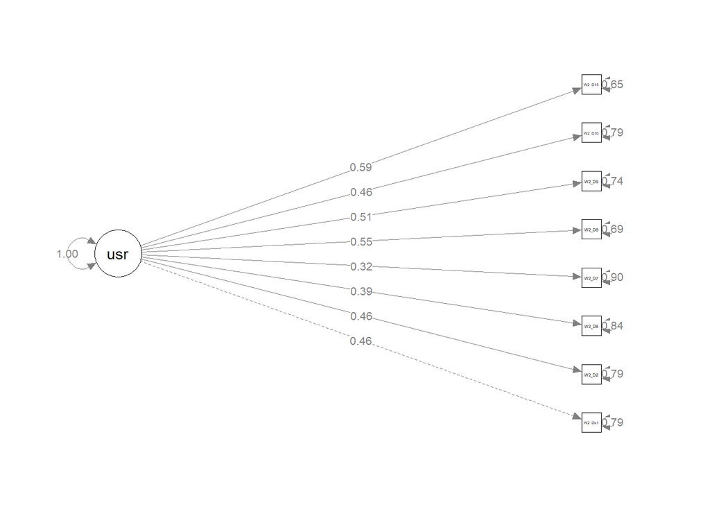

#To Repeat the procedure with a different estimator, change the estimator (ML).

After having confirmed the model, we will proceed with the IRT Step 1 pachages run (if aleardy installed)

Define data

```r
data<-haven::read_sav("Data.sav")%>%
  mutate_if(is.character, as.factor)
describe(data)
```

```
##             vars   n    mean      sd median trimmed     mad min  max range
## ID             1 477 4835.31 2726.94   4802 4868.40 3398.12   1 9458  9457
## w2_res1        2 475    3.39    1.31      3    3.39    1.48   1    7     6
## w2_res2        3 477    3.32    1.32      3    3.28    1.48   1    7     6
## w2_res3        4 476    4.63    1.30      5    4.69    1.48   1    7     6
## w2_res3R       5 476    3.37    1.30      3    3.31    1.48   1    7     6
## w2_res4        6 473    4.33    1.66      4    4.36    1.48   1    7     6
## w2_res5        7 476    3.53    1.74      3    3.48    1.48   1    7     6
## w2_res6        8 477    3.46    1.53      3    3.41    1.48   1    7     6
## w2_res7        9 477    2.76    1.36      3    2.63    1.48   1    7     6
## w2_res8       10 474    4.32    1.34      4    4.37    1.48   1    7     6
## w2_res8R      11 474    3.68    1.34      4    3.63    1.48   1    7     6
## w2_res9       12 476    3.88    1.43      4    3.85    1.48   1    7     6
## w2_res10      13 476    4.78    1.64      5    4.88    1.48   1    7     6
## w2_res10R     14 476    3.22    1.64      3    3.12    1.48   1    7     6
## w2_res11      15 475    2.24    1.39      2    2.00    1.48   1    7     6
## w2_res11R     16 475    5.76    1.39      6    6.00    1.48   1    7     6
## w2_res12      17 477    2.59    1.26      2    2.46    1.48   1    7     6
## w2_res13      18 474    2.34    1.12      2    2.24    1.48   1    6     5
## w2_res14      19 475    3.79    1.45      4    3.76    1.48   1    7     6
## w2_res14R     20 475    4.21    1.45      4    4.24    1.48   1    7     6
## w2_res15      21 476    4.35    1.17      4    4.40    1.48   1    7     6
## w2_res15R     22 476    3.65    1.17      4    3.60    1.48   1    7     6
## w2_av1        23 476    2.33    1.31      2    2.18    1.48   1    7     6
## w2_av2        24 476    2.41    1.29      2    2.27    1.48   1    7     6
## w2_av3        25 477    5.63    1.43      6    5.81    1.48   1    7     6
## w2_av3R       26 477    2.37    1.43      2    2.19    1.48   1    7     6
## w2_av4        27 474    4.13    1.87      4    4.17    1.48   1    7     6
## w2_av5        28 474    3.76    1.92      4    3.70    2.97   1    7     6
## w2_av6        29 476    2.41    1.49      2    2.19    1.48   1    7     6
## w2_av7        30 475    2.61    1.55      2    2.42    1.48   1    7     6
## w2_av8        31 475    5.40    1.50      6    5.57    1.48   1    7     6
## w2_av8R       32 475    2.60    1.50      2    2.43    1.48   1    7     6
## w2_av9        33 476    2.96    1.66      3    2.80    1.48   1    7     6
## w2_av10       34 475    5.01    1.45      5    5.07    1.48   1    7     6
## w2_av10R      35 475    2.99    1.45      3    2.93    1.48   1    7     6
## w2_av11       36 477    2.81    2.26      2    2.52    1.48   1    7     6
## w2_av11R      37 477    5.19    2.26      6    5.48    1.48   1    7     6
## w2_av12       38 475    2.87    1.74      3    2.66    1.48   1    7     6
## w2_av13       39 475    2.72    1.59      2    2.54    1.48   1    7     6
```

[output cut: 73 more lines]

```
## W2_Dis5     -0.05    -0.08   0.11
## W2_Dis6     -0.15     0.52   0.09
## W2_Dis7     -0.39     0.95   0.08
## W2_Dis8     -0.02     0.72   0.08
## W2_Dis9     -0.03     0.11   0.09
## W2_Dis10    -0.30     0.38   0.09
## W2_Dis11    -0.63     0.41   0.10
## W2_Dis12    -0.24     0.55   0.09
## W2_Dis13    -0.42     0.53   0.08
## W2_Dis14     0.07     0.39   0.09
## W2_Dis15    -0.17     0.76   0.07
## W2_Dis8Rev   0.02     0.72   0.08
## W2_Dis10Rev  0.30     0.38   0.09
## W2_Dis14Rev -0.07     0.39   0.09
## W2_Dis15Rev  0.17     0.76   0.07
```

```r
view(data)
```

Then we select only the variables we need for our analysis

```r
myvars <- c("W2_Dis1", "W2_Dis2", "W2_Dis6", "W2_Dis7", "W2_Dis8Rev", "W2_Dis9", "W2_Dis10Rev", "W2_Dis15Rev"
)
data1<-data[myvars]
describe(data1)
```

```
##             vars   n mean   sd median trimmed  mad min max range  skew kurtosis
## W2_Dis1        1 474 1.07 1.61      1    1.10 1.48  -5   6    11 -0.26     0.58
## W2_Dis2        2 476 0.91 1.63      1    0.93 1.48  -5   6    11 -0.13     0.58
## W2_Dis6        3 476 1.04 2.00      1    1.06 1.48  -5   6    11 -0.15     0.52
## W2_Dis7        4 475 0.15 1.83      0    0.21 1.48  -6   6    12 -0.39     0.95
## W2_Dis8Rev     5 472 1.09 1.78      1    1.07 1.48  -6   6    12  0.02     0.72
## W2_Dis9        6 475 0.93 2.06      1    0.94 1.48  -5   6    11 -0.03     0.11
## W2_Dis10Rev    7 474 0.23 1.97      0    0.16 1.48  -6   6    12  0.30     0.38
## W2_Dis15Rev    8 476 1.44 1.52      1    1.42 1.48  -4   6    10  0.17     0.76
##               se
## W2_Dis1     0.07
## W2_Dis2     0.07
## W2_Dis6     0.09
## W2_Dis7     0.08
## W2_Dis8Rev  0.08
## W2_Dis9     0.09
## W2_Dis10Rev 0.09
## W2_Dis15Rev 0.07
```

re-view data and define the scale

```r
glimpse(data1)
```

```
## Rows: 477
## Columns: 8
## $ W2_Dis1     <dbl> 4, 4, 3, -2, 2, 1, 2, 1, 2, 1, 0, 0, -1, 3, 3, 3, 2, 1, 0,~
## $ W2_Dis2     <dbl> 4, 3, 6, 3, 4, 4, 3, 0, 1, 0, -1, 0, -1, 1, 2, 3, 1, 0, 0,~
## $ W2_Dis6     <dbl> 2, 3, 4, 2, 2, 0, 0, -1, 0, 0, 0, 0, 0, 1, 2, 4, 0, 4, 2, ~
## $ W2_Dis7     <dbl> 0, 3, 1, -5, 2, 0, -1, 0, -2, 1, -1, 2, 0, 1, 1, 1, 0, -1,~
## $ W2_Dis8Rev  <dbl> 0, 3, 2, 3, 1, 1, 2, -1, 2, 1, 1, 1, -1, 2, 1, 1, 3, 0, -1~
## $ W2_Dis9     <dbl> 1, 3, 5, 2, 4, -1, 0, -1, -1, -2, 0, 3, 1, 1, -2, 2, 2, 2,~
## $ W2_Dis10Rev <dbl> 0, 4, 0, -4, 4, -5, -2, -1, 0, -2, -2, 0, 0, 0, 0, 2, 3, -~
## $ W2_Dis15Rev <dbl> 3, 3, 3, 3, 0, 2, 2, 2, 0, 2, -1, 2, 2, 3, 3, 2, 4, 1, 2, ~
```

```r
scale <-(data1)

head(scale, 8)
```

```
## # A tibble: 8 x 8
##   W2_Dis1 W2_Dis2 W2_Dis6 W2_Dis7 W2_Dis8Rev W2_Dis9 W2_Dis10Rev W2_Dis15Rev
##     <dbl>   <dbl>   <dbl>   <dbl>      <dbl>   <dbl>       <dbl>       <dbl>
## 1       4       4       2       0          0       1           0           3
## 2       4       3       3       3          3       3           4           3
## 3       3       6       4       1          2       5           0           3
## 4      -2       3       2      -5          3       2          -4           3
## 5       2       4       2       2          1       4           4           0
## 6       1       4       0       0          1      -1          -5           2
## 7       2       3       0      -1          2       0          -2           2
## 8       1       0      -1       0         -1      -1          -1           2
```

Fit the graded response model using the ‘mirt’ R package.

```
## "W2_Dis8Rev" re-mapped to ensure all categories have a distance of 1
```

```
## Sample size after row-wise response data removal: 459
```

```
##             M2 df            p      RMSEA    RMSEA_5  RMSEA_95      SRMSR
## stats 94.52615 20 1.185985e-11 0.09020001 0.07228525 0.1087782 0.06674021
```

```r
itemfit(mod1, na.rm = TRUE)
```

```
## Sample size after row-wise response data removal: 459
```

```
##          item    S_X2 df.S_X2 RMSEA.S_X2 p.S_X2
## 1     W2_Dis1  90.312      99      0.000  0.722
## 2     W2_Dis2  94.430      95      0.000  0.497
## 3     W2_Dis6 123.889     118      0.010  0.337
## 4     W2_Dis7 145.904     108      0.028  0.009
## 5  W2_Dis8Rev 115.819     101      0.018  0.149
## 6     W2_Dis9 125.263     120      0.010  0.353
## 7 W2_Dis10Rev 122.641     124      0.000  0.518
## 8 W2_Dis15Rev  90.106      84      0.013  0.305
```

Examine IRT parameters (0 = non discriminative; 0.01–0.34 = very low; 0.35–0.64 = low; 0.65–1.34 = moderate; 1.35–1.69 = high; >1.70 = very high; Baker, 2001)

```
##                     a        b1        b2        b3        b4        b5
## W2_Dis1     1.2033812 -5.753107 -4.837215 -3.674272 -2.715240 -2.052186
## W2_Dis2     1.2298251 -5.657421 -4.526699 -3.477328 -2.668506 -1.798430
## W2_Dis6     1.0615840 -4.811033 -4.142462 -3.279788 -2.634424 -1.865611
## W2_Dis7     0.8036281 -6.705555 -5.318943 -4.580861 -3.330335 -2.401604
## W2_Dis8Rev  1.2822607 -5.418420 -4.553949 -3.252645 -2.661278 -1.865100
## W2_Dis9     1.1639431 -4.927078 -3.851845 -3.007046 -2.197782 -1.408447
## W2_Dis10Rev 0.7980509 -7.233385 -6.719474 -5.642235 -3.487192 -2.195918
## W2_Dis15Rev 1.3117336 -5.422397 -4.314520 -3.527245 -2.345960 -1.028045
##                     b6        b7       b8       b9      b10      b11      b12
## W2_Dis1     -0.6418868 0.4521075 1.668518 2.622101 4.532010 5.789916       NA
## W2_Dis2     -0.3500712 0.6493051 1.684483 2.874701 4.274311 5.101288       NA
## W2_Dis6     -0.4365800 0.4660534 1.457749 2.422384 3.292712 4.361987       NA
## W2_Dis7     -1.3868753 0.5066756 1.940914 3.206168 4.683504 6.671817 8.059164
## W2_Dis8Rev  -0.5028195 0.3960155 1.458178 2.325062 2.965665 4.207108       NA
## W2_Dis9     -0.3167869 0.4886917 1.264591 2.362515 3.179687 3.860828       NA
## W2_Dis10Rev -0.9409435 0.6074190 1.644943 2.605570 3.800691 4.526885 6.754988
## W2_Dis15Rev  0.1435927 1.1817495 2.474795 3.260924 3.864729       NA       NA
```

Examine items parameters/loadings and communalities

```r
summary(mod1)
```

```
##                F1    h2
## W2_Dis1     0.577 0.333
## W2_Dis2     0.586 0.343
## W2_Dis6     0.529 0.280
## W2_Dis7     0.427 0.182
## W2_Dis8Rev  0.602 0.362
## W2_Dis9     0.564 0.319
## W2_Dis10Rev 0.425 0.180
## W2_Dis15Rev 0.610 0.373
##
## SS loadings:  2.372
## Proportion Var:  0.297
##
## Factor correlations:
##
##    F1
## F1  1
```

Produce IRT plots - Category characteristic Curve

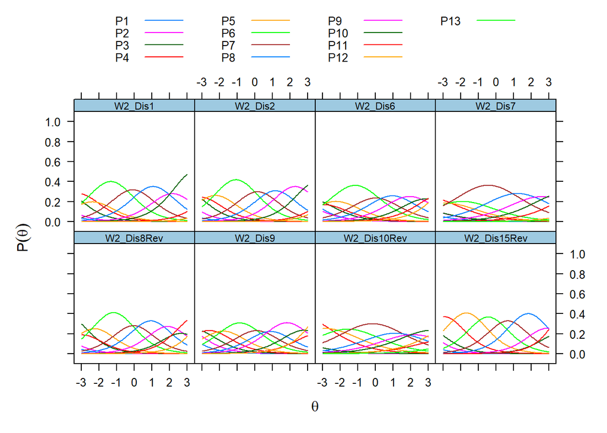

Produce the Item information Curves

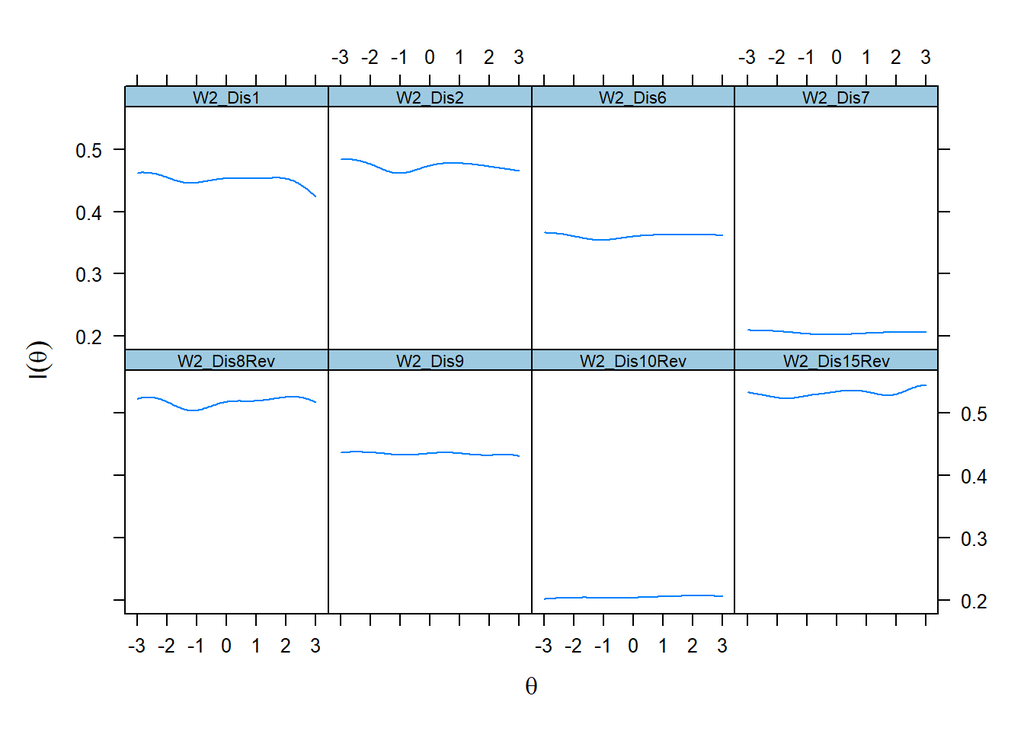

Scale information and conditional standard errors

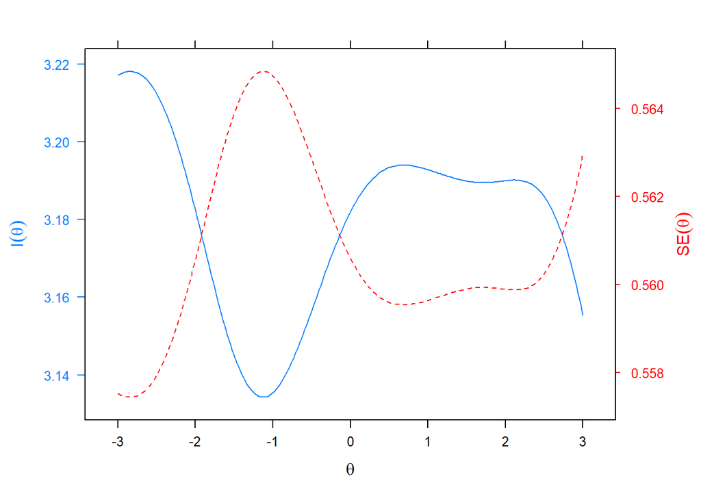

Produce the Conditional reliability if chosen

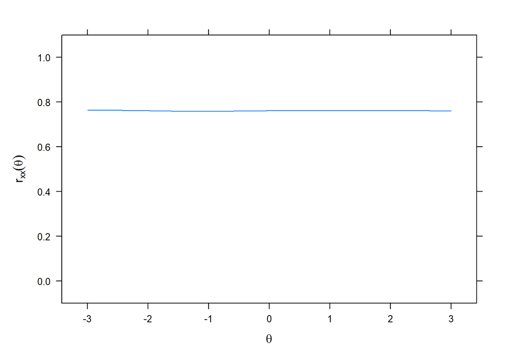

```
## [1] 0.7604046
```

Scale characteristic Curve

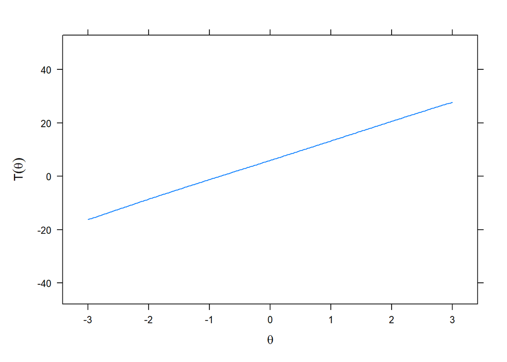